# COMPSCIX 415.2 Homework 2

ggplot2 works independently with each declared aesthetic and layer one above the other. In the example below cyl is associated with size and color aesthetics.

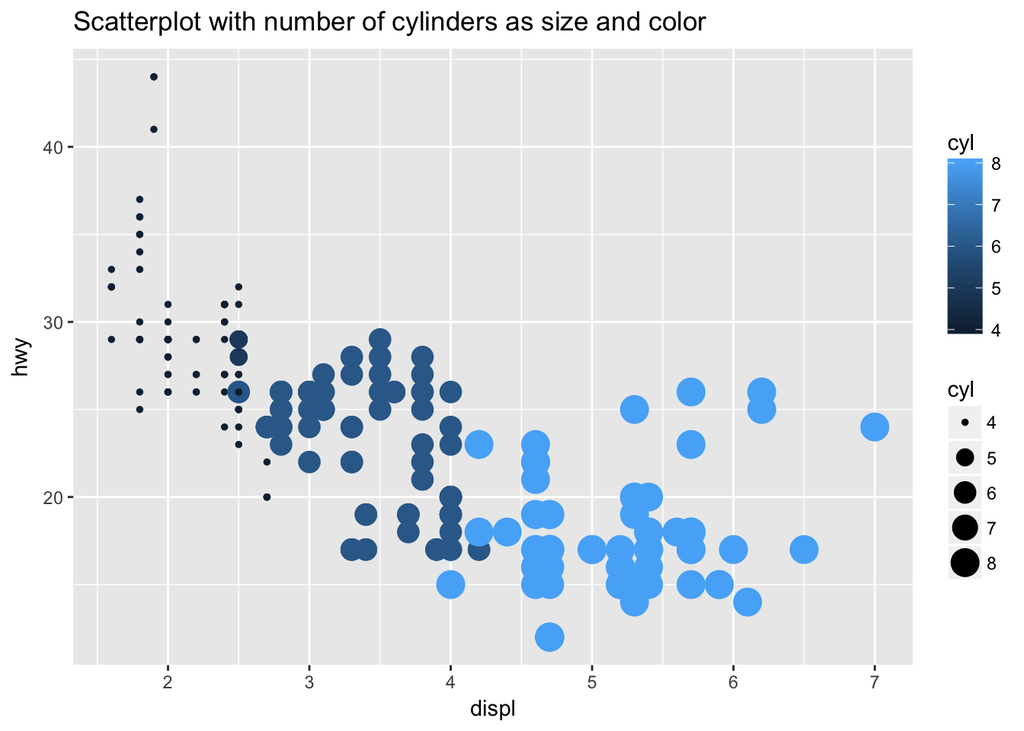

```r
ggplot(data = mpg) +
  geom_point(mapping = aes(x = displ, y = hwy, size = cyl, color = cyl)) + labs(title = "Scatterplot with number of cylinders as size and color")
```

**Q:** What does the stroke aesthetic do? What shapes does it work with?

Stroke aesthetic defines the thickness of the border of a shape. **Example:**

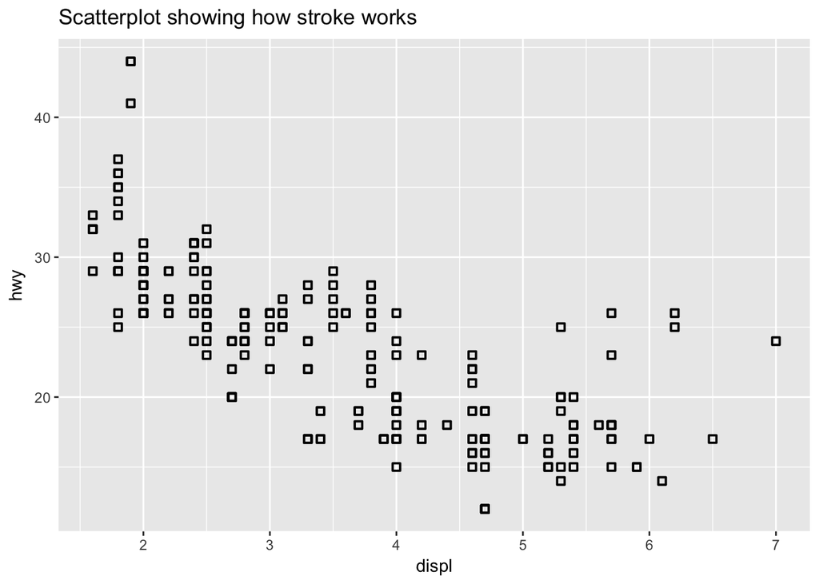

```r
ggplot(data = mpg) +
  geom_point(mapping = aes(x = displ, y = hwy), shape=0, stroke=1) + labs(title = "Scatterplot showing how stroke works")
```

**Q:** What happens if you map an aesthetic to something other than a variable name, like aes(colour = displ < 5)?

When an aesthetic is mapped to something other than a raw variable, ggplot2 resolves the property and assign unique level for each distinct value in the outcome.

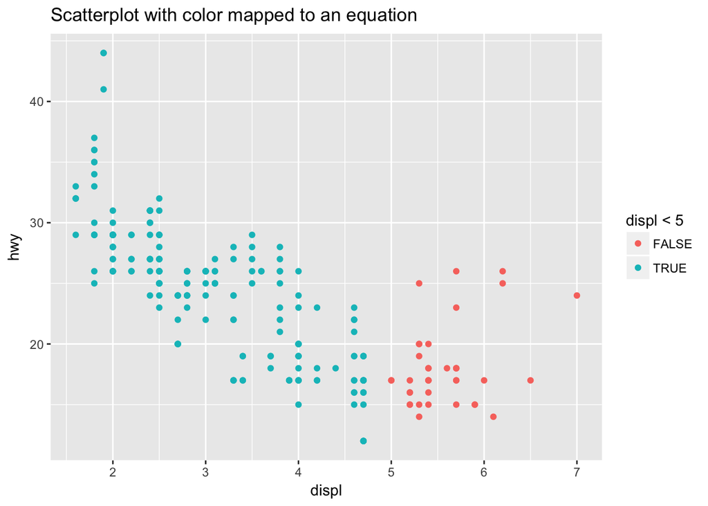

```r
ggplot(data = mpg) +
  geom_point(mapping = aes(x = displ, y = hwy, color = displ < 5)) + labs(title = "Scatterplot with color mapped to an equation")
```

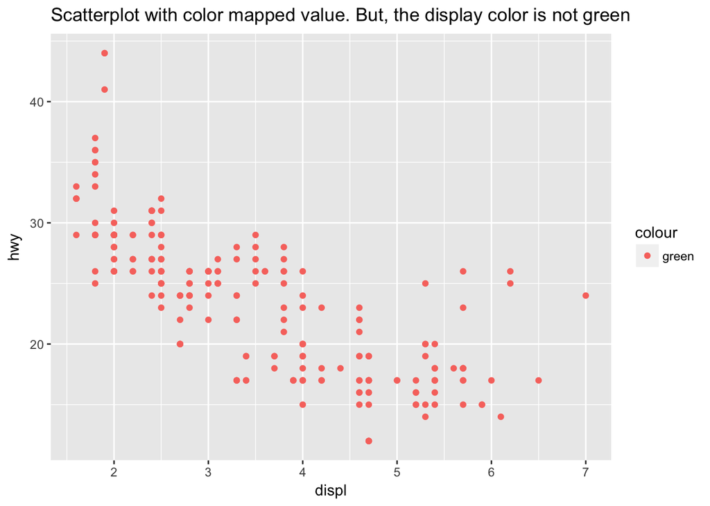

```r
ggplot(data = mpg) +
  geom_point(mapping = aes(x = displ, y = hwy, color = 'green')) + labs(title = "Scatterplot with color mapped value. But, the display color is not green")
```